# ETC5521: Diving Deeply into Data Exploration

## Non box-cox example: Olive oil (1/2)

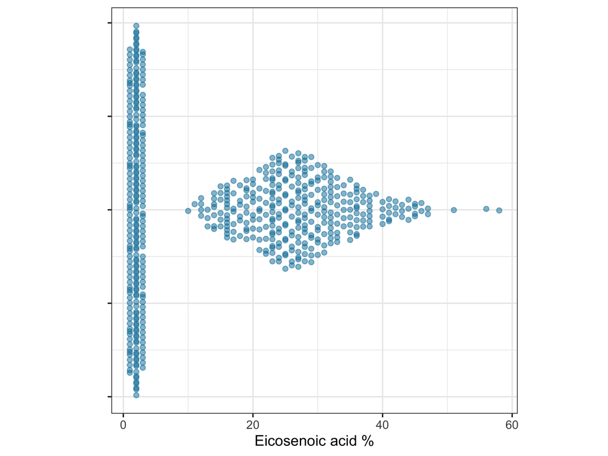

```r
ggplot(olive, aes(x = eicosenoic, y = 1)) +
  geom_quasirandom(colour = "#007BA5", alpha = 0.5) +
  ylab("") +
  xlab("Eicosenoic acid %") +
  theme(axis.text.y = element_blank())
```

Two clusters

Check if there is another variable that explains the two groups

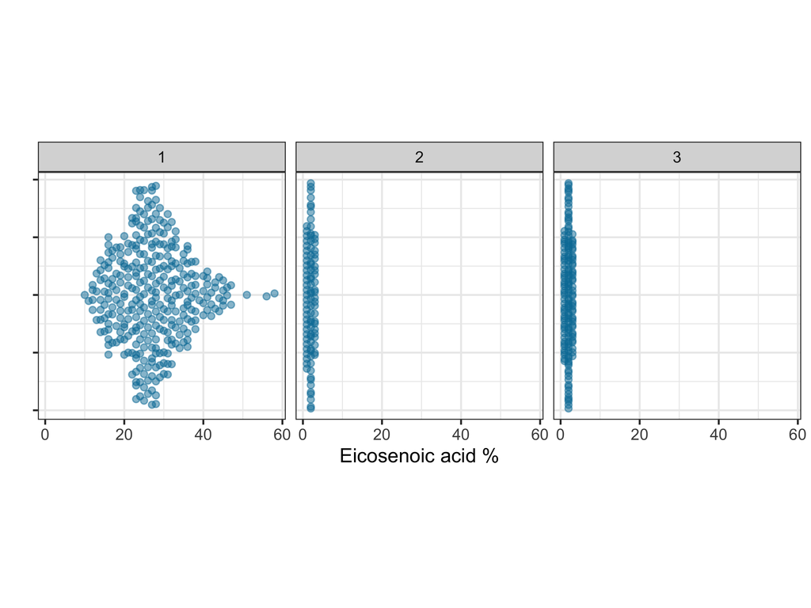

```r
ggplot(olive, aes(x = eicosenoic, y = 1)) +
  geom_quasirandom(colour = "#007BA5", alpha = 0.5) +
  facet_wrap(~region, ncol=3) +
  ylab("") +
  xlab("Eicosenoic acid %") +
  theme(axis.text.y = element_blank())
```

## Non box-cox example: Olive oil (2/2)

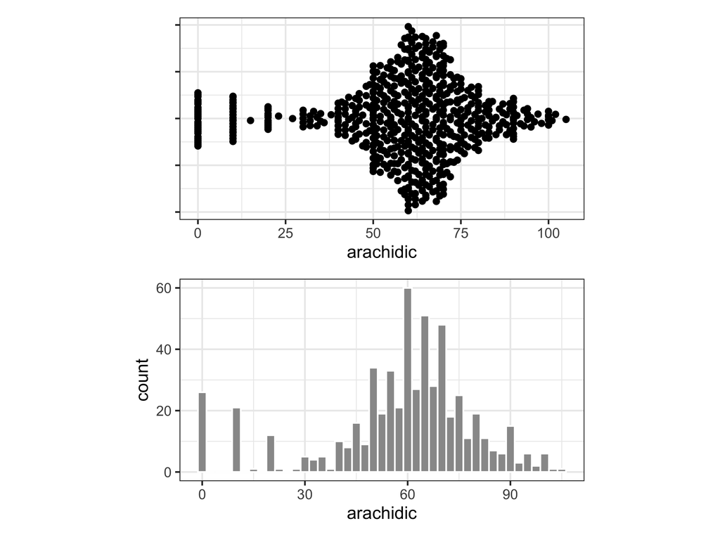

Mixture of discreteness and normal shape of continuous values. *Why might this happen?*

Check if there is a difference in the strata (here 1 thru 9), implying measurement policy differences.

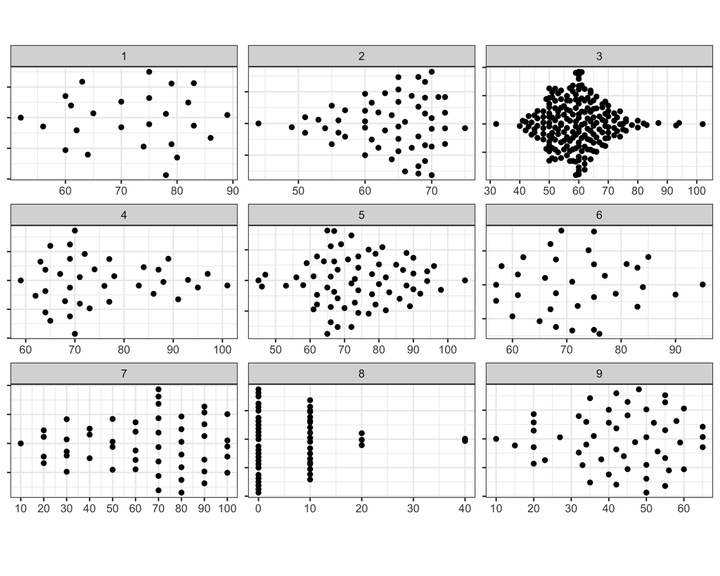

## Activity: Air quality

**Your turn**

When and why do you want to make a transformation of a variable?

## Handling missing values

## Melbourne Housing Prices (1/5)

```r
df2 |>
  head(20) |>
  select(Suburb, Rooms, Type, Price, Date) |>
  mutate(
    Price = scales::comma(Price),
    Type = fct_recode(Type,
      "Home" = "h",
      "Townhouse" = "t",
      "Unit" = "u"
    )
  ) |>
  knitr::kable(
    col.names = c("Suburb", "Rooms", "Type", "Price ($)", "Date"),
    align = "lrlr"
  ) |>
  kableExtra::kable_classic() |>
  kableExtra::kable_styling(font_size = 24,
    full_width=FALSE)
```

| Suburb | Rooms | Type | Price ($) | Date |
| --- | --- | --- | --- | --- |
| Abbotsford | 3 | Home | 1,490,000 | 2017-04-01 |
| Abbotsford | 3 | Home | 1,220,000 | 2017-04-01 |
| Abbotsford | 3 | Home | 1,420,000 | 2017-04-01 |
| Aberfeldie | 3 | Home | 1,515,000 | 2017-04-01 |
| Airport West | 2 | Home | 670,000 | 2017-04-01 |
| Airport West | 2 | Townhouse | 530,000 | 2017-04-01 |
| Airport West | 2 | Unit | 540,000 | 2017-04-01 |
| Airport West | 3 | Home | 715,000 | 2017-04-01 |
| Albanvale | 6 | Home | NA | 2017-04-01 |
| Albert Park | 3 | Home | 1,925,000 | 2017-04-01 |
| Albion | 3 | Unit | 515,000 | 2017-04-01 |
| Albion | 4 | Home | 717,000 | 2017-04-01 |
| Alphington | 2 | Home | 1,675,000 | 2017-04-01 |
| Alphington | 4 | Home | 2,008,000 | 2017-04-01 |
| Altona | 2 | Home | 860,000 | 2017-04-01 |
| Altona Meadows | 4 | Home | NA | 2017-04-01 |
| Altona North | 3 | Home | 720,000 | 2017-04-01 |
| Armadale | 2 | Unit | 836,000 | 2017-04-01 |
| Armadale | 2 | Home | 2,110,000 | 2017-04-01 |
| Armadale | 3 | Home | 1,386,000 | 2017-04-01 |

- This data was scraped each week from domain.com.au from 2016-01-28 to 2018-10-13
- In total there are **63,023** observations
- All variables shown (there are more variables not shown here), except price, have complete records
- The are **48,433** property prices across Melbourne (roughly 23% missing)

Data source: Tony Pio (2018) [Melbourne Housing Market](https://www.kaggle.com/anthonypino/melbourne-housing-market)

**How would you explore this data first?**

*Yes, with an overview plot.*

## Melbourne Housing Prices (2/5)

- 📊
- data
- R
- lineup
- R

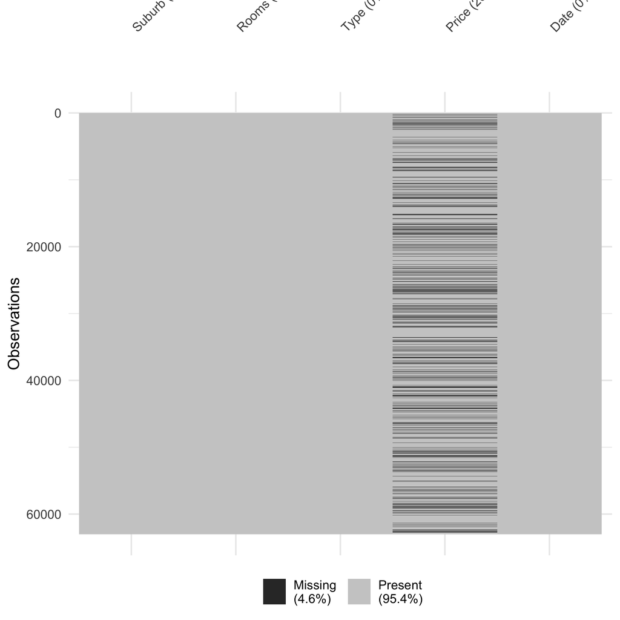

There are only missings on price, but a lot of them. Can we find some other collected variable which might help to explain the missing price?

Is missingness more likely for expensive houses?

Use a substitute like `Rooms` to examine the possible relationship. Show `Rooms` vs missing on `Price` and use a lineup before looking at the data.

`Rooms` is discrete, so a bar chart, possibly facaetted or side-by-side bars, would be a suitable plot.

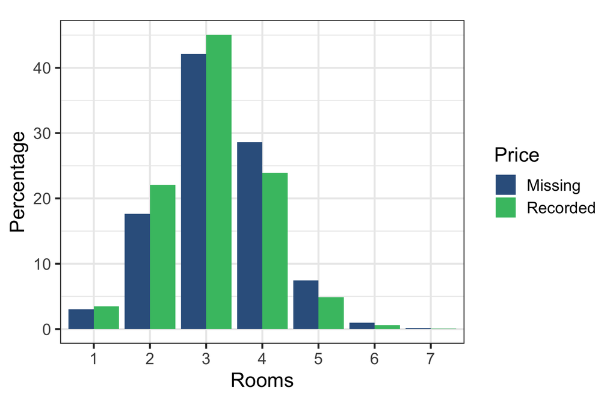

- To impute missings other variables will need to be used.

```r
df2 <- read_csv(here::here("data/MELBOURNE_HOUSE_PRICES_LESS.csv"),
  col_types = cols(
    .default = col_character(),
    Rooms = col_double(),
    Price = col_double(),
    Date = col_date(format = "%d/%m/%Y"),
    Propertycount = col_double(),
    Distance = col_double()
  )
)
```

```r
skimr::skim(df2)
```

```
── Data Summary ────────────────────────
                           Values
Name                       df2
Number of rows             63023
Number of columns          13
_______________________
Column type frequency:
  character                8
  Date                     1
  numeric                  4
________________________
Group variables            None

── Variable type: character ────────────────────────────────
  skim_variable n_missing complete_rate min max empty
1 Suburb                0             1   3  18     0
2 Address               0             1   7  27     0
3 Type                  0             1   1   1     0
4 Method                0             1   1   2     0
5 SellerG               0             1   1  27     0
6 Postcode              0             1   4   4     0
7 Regionname            0             1  16  26     0
8 CouncilArea           0             1  17  30     0
  n_unique whitespace
1      380          0
2    57754          0
3        3          0
4        9          0
5      476          0
6      225          0
7        8          0
8       34          0

── Variable type: Date ─────────────────────────────────────
  skim_variable n_missing complete_rate min
1 Date                  0             1 2016-01-28
  max        median     n_unique
1 2018-10-13 2017-09-03      112

── Variable type: numeric ──────────────────────────────────
  skim_variable n_missing complete_rate      mean         sd
1 Rooms                 0         1          3.11      0.958
2 Price             14590         0.768 997898.   593499.
3 Propertycount         0         1       7618.     4424.
4 Distance              0         1         12.7       7.59
     p0    p25      p50       p75       p100 hist
1     1      3      3         4         31   ▇▁▁▁▁
2 85000 620000 830000   1220000   11200000   ▇▁▁▁▁
3    39   4380   6795     10412      21650   ▅▇▅▂▁
4     0      7     11.4      16.7       64.1 ▇▆▁▁▁
```

```r
df2 |>
  select(Suburb, Rooms, Type, Price, Date) |>
  arrange(Suburb, Date) |>
  visdat::vis_miss()
```

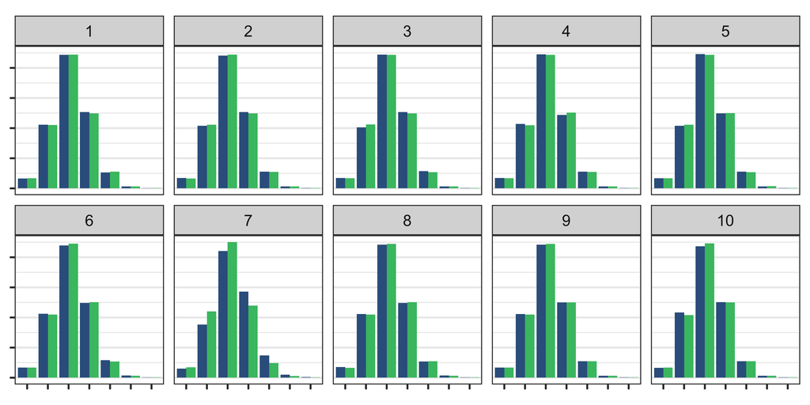

```r
df2 |>
  mutate(miss = ifelse(is.na(Price),
    "Missing", "Recorded")) |>
  count(Rooms, miss) |>
  filter(Rooms < 8) |>
  group_by(miss) |>
  mutate(perc = n / sum(n) * 100) |>
  ggplot(aes(as.factor(Rooms), perc, fill = miss)) +
    geom_col(position = "dodge") +
    scale_fill_viridis_d(begin=0.3, end=0.7) +
    labs(x = "Rooms", y = "Percentage", fill = "Price") +
    theme(aspect.ratio = 0.8)
```

Is there a suspicious plot?

Break the association between Rooms and Missing/Not on Price, because the null hypothesis is that there is no difference in missing status for price based on the size of the house. Why?

```r
library(nullabor)
df2_d <- df2 |>
  mutate(miss = ifelse(is.na(Price), "Missing", "Recorded")) |>
  select(Rooms, miss) |>
  filter(Rooms < 8)
df2_l <- lineup(null_permute("miss"), df2_d, n=10, pos=7)
df2_l_agg <- df2_l |>
  group_by(.sample) |>
  count(Rooms, miss) |>
  ungroup() |>
  group_by(miss) |>
  mutate(perc = n / sum(n) * 100) |>
  mutate(Rooms = as.factor(Rooms))
ggplot(df2_l_agg, aes(x=Rooms, y=perc, fill = miss)) +
  geom_col(position = "dodge") +
  scale_fill_viridis_d(begin=0.3, end=0.7) +
  facet_wrap(~.sample, ncol=5) +
  theme(legend.position = "none",
        axis.text = element_blank(),
        axis.title = element_blank(),
        panel.grid.major.x = element_blank())
```

## Check the **support** of your data

If you have too few measurements in any region (extreme), summaries for these regions will be unreliable.

- For quantitative variables, it may be necessary to remove extremes.
- If the variable is categorical it might be best to combine levels.
- It is important to script so decisions can be reversed or rare events are not ignored.

We removed houses with 8 or more rooms. What other way might we have handled these houses?

## Melbourne Housing Prices (3/5)

- 📊
- data
- R

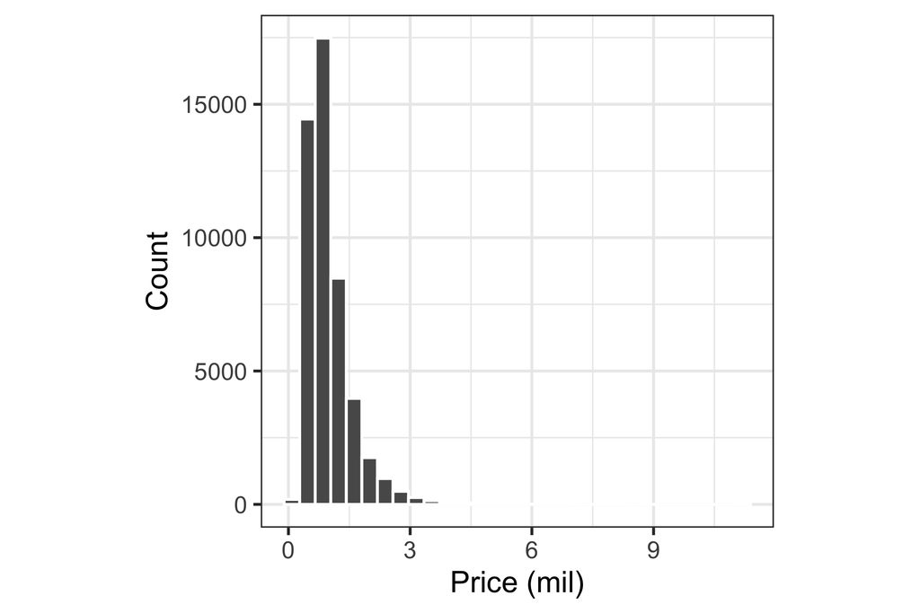

**What can we say from this plot?**

- The housing prices are right-skewed
- There appears to be a lot of outlying housing prices (how can we tell?)

Note: We determined that it is likely that more higher price houses have not disclosed the sale price. The distribution of price will need to be checked again after imputation.

```r
df2 <- read_csv(here::here("data/MELBOURNE_HOUSE_PRICES_LESS.csv"),
  col_types = cols(
    .default = col_character(),
    Rooms = col_double(),
    Price = col_double(),
    Date = col_date(format = "%d/%m/%Y"),
    Propertycount = col_double(),
    Distance = col_double()
  )
)
```

```r
df2 |>
  ggplot(aes(Price / 1e6)) +
  geom_histogram(color = "white") +
  labs(
    x = "Price (mil)",
    y = "Count"
  )
```

## Melbourne Housing Prices (4/5)

- 📊
- data
- R

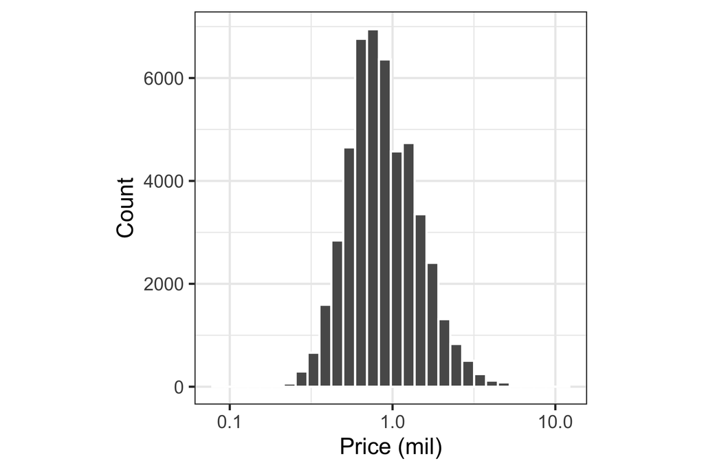

- The x-axis has been $\log_{10}$-transformed in this plot
- The plot appears more symmetrical now
- What is a useful measure of central tendency here?

```r
df2 <- read_csv(here::here("data/MELBOURNE_HOUSE_PRICES_LESS.csv"),
  col_types = cols(
    .default = col_character(),
    Rooms = col_double(),
    Price = col_double(),
    Date = col_date(format = "%d/%m/%Y"),
    Propertycount = col_double(),
    Distance = col_double()
  )
)
```

```r
df2 |>
  ggplot(aes(Price / 1e6)) +
  geom_histogram(color = "white") +
  labs(
    x = "Price (mil)",
    y = "Count"
  ) +
  scale_x_log10()
```

## Melbourne Housing Prices (5/5)

- Central tendency
- R

With no transformation:

| Mean | Median | Trimmed Mean | Winsorised Mean |
| --- | --- | --- | --- |
| $997,898 | $830,000 | $871,375 | $903,823 |

With log transformation (and back-transformed to original scale):

| Mean | Median | Trimmed Mean | Winsorised Mean |
| --- | --- | --- | --- |
| $874,166 | $830,000 | $847,973 | $859,325 |

```r
df2 |>
  filter(!is.na(Price)) |>
  summarise(
    Mean = scales::dollar(mean(Price)),
    Median = scales::dollar(median(Price)),
    `Trimmed Mean` = scales::dollar(mean(Price, trim = 0.2)),
    `Winsorised Mean` = scales::dollar(psych::winsor.mean(Price))
  ) |>
  knitr::kable(align = "r") |>
  kableExtra::kable_classic() |>
  kableExtra::kable_styling(full_width=FALSE)
```

```r
df2 |>
  filter(!is.na(Price)) |>
  mutate(lPrice = log10(Price)) |>
  summarise(
    Mean = scales::dollar(10^mean(lPrice)),
    Median = scales::dollar(10^median(lPrice)),
    `Trimmed Mean` = scales::dollar(10^mean(lPrice, trim = 0.2)),
    `Winsorised Mean` = scales::dollar(10^psych::winsor.mean(lPrice))
  ) |>
  knitr::kable(align = "r") |>
  kableExtra::kable_classic() |>
  kableExtra::kable_styling(full_width=FALSE)
```

## Categorical variables

## There are two types of categorical variables

**Nominal** where there is no intrinsic ordering to the categories  
**E.g.** blue, grey, black, white.

**Ordinal** where there is a clear order to the categories.  
**E.g.** Strongly disagree, disagree, neutral, agree, strongly agree.

## Categorical variables in R

- In R, categorical variables may be encoded as **factors**.

```r
data <- c(2, 2, 1, 1, 3, 3, 3, 1)
factor(data)
```

```
[1] 2 2 1 1 3 3 3 1
Levels: 1 2 3
```

- You can easily change the labels of the variables:

```r
factor(data, labels = c("I", "II", "III"))
```

```
[1] II  II  I   I   III III III I
Levels: I II III
```

- Order of the factors are determined by the input:

```r
# numerical input are ordered in increasing order
factor(c(1, 3, 10))
```

```
[1] 1  3  10
Levels: 1 3 10
```

```r
# character input are ordered by first char, alphabetically
factor(c("1", "3", "10"))
```

```
[1] 1  3  10
Levels: 1 10 3
```

```r
# you can specify order of levels explicitly
factor(c("1", "3", "10"),
  levels = c("1", "3", "10")
)
```

```
[1] 1  3  10
Levels: 1 3 10
```

## Order nominal variables meaningfully

**Coding tip**: use below functions to easily change the order of factor levels

```r
stats::reorder(factor, value, mean)
forcats::fct_reorder(factor, value, median)
forcats::fct_reorder2(factor, value1, value2, func)
```

## Numerical summaries

counts, proportions, percentages and odds

Tuberculosis counts in Australia

```r
options(digits=2)
tb_oz |>
  filter(year >= 2000) |>
  mutate(p = count/sum(count),
         pct = p*100,
         odds = count/count[year==2000]) |>
  print(n=100)
```

```
# A tibble: 22 × 7
   country   iso3   year count      p   pct  odds
   <chr>     <chr> <dbl> <dbl>  <dbl> <dbl> <dbl>
 1 Australia AUS    2000   982 0.0522  5.22 1
 2 Australia AUS    2001   953 0.0507  5.07 0.970
 3 Australia AUS    2002  1008 0.0536  5.36 1.03
 4 Australia AUS    2003   926 0.0493  4.93 0.943
 5 Australia AUS    2004  1036 0.0551  5.51 1.05
 6 Australia AUS    2005  1030 0.0548  5.48 1.05
 7 Australia AUS    2006  1127 0.0600  6.00 1.15
 8 Australia AUS    2007  1081 0.0575  5.75 1.10
 9 Australia AUS    2008  1182 0.0629  6.29 1.20
10 Australia AUS    2009  1176 0.0626  6.26 1.20
11 Australia AUS    2010  1146 0.0610  6.10 1.17
12 Australia AUS    2011  1202 0.0640  6.40 1.22
13 Australia AUS    2012  1259 0.0670  6.70 1.28
14 Australia AUS    2013   512 0.0272  2.72 0.521
15 Australia AUS    2014   474 0.0252  2.52 0.483
16 Australia AUS    2015   438 0.0233  2.33 0.446
17 Australia AUS    2016   481 0.0256  2.56 0.490
18 Australia AUS    2017   524 0.0279  2.79 0.534
19 Australia AUS    2018   502 0.0267  2.67 0.511
20 Australia AUS    2019   554 0.0295  2.95 0.564
21 Australia AUS    2020   609 0.0324  3.24 0.620
22 Australia AUS    2021   593 0.0316  3.16 0.604
```

For qualitative data, compute

- count/frequency,
- proportion/percentage
- and sometimes, an **odds ratio**. Here we have used ratio relative to the count in year 2000.

**Note:** For exploration, no rounding of digits was done, but to report you would need to make the numbers pretty.

## Ways to plot a single categorical variable

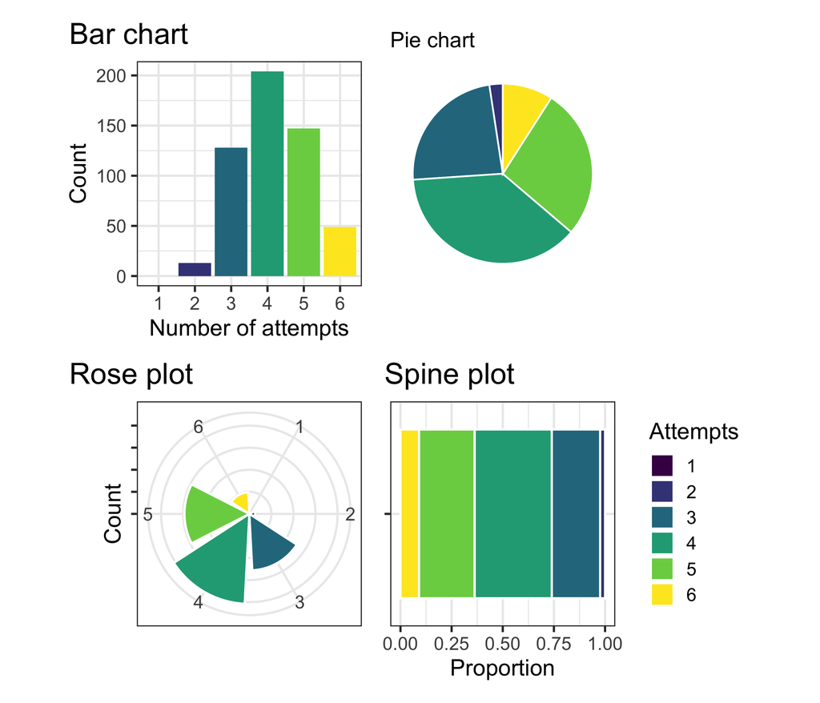

```r
wordle2 <- wordle |>
  mutate(attempts = factor(rows))

p_bar <- ggplot(wordle2, aes(x = attempts, y = count)) +
  geom_col(aes(fill = attempts)) +
  scale_fill_viridis_d() +
  labs(x = "Number of attempts", y = "Count") +
  theme(legend.position = "none") +
  ggtitle("Bar chart")

p_pie <- ggplot(wordle2, aes(x = "", y = count, fill = attempts)) +
  geom_col(width = 1, colour = "white") +
  coord_polar(theta = "y") +
  scale_fill_viridis_d() +
  labs(fill = "Attempts", x = NULL, y = NULL) +
  theme_void() +
  theme(legend.position = "none") +
  ggtitle("Pie chart")

p_rose <- ggplot(wordle2, aes(x = attempts, y = count, fill = attempts)) +
  geom_col(colour = "white") +
  coord_polar(theta = "x") +
  scale_fill_viridis_d() +
  labs(x = NULL, y = "Count", fill = "Attempts") +
  theme(axis.text.y = element_blank(), legend.position = "none") +
  ggtitle("Rose plot")

p_spine <- ggplot(wordle2, aes(x = "", y = count, fill = attempts)) +
  geom_col(position = "fill", colour = "white") +
  scale_fill_viridis_d() +
  coord_flip() +
  labs(x = NULL, y = "Proportion", fill = "Attempts") +
  theme(axis.text.y = element_blank()) +
  ggtitle("Spine plot")

p_bar + p_pie + p_rose + p_spine + plot_layout(ncol=2)
```

Number of attempts to solve Wordle:

- Bar chart: height encodes count directly – easiest to compare categories accurately
- Pie chart: angle (and area) encodes count – comparing categories by angle is harder than by length
- Rose plot (nightingale/coxcomb): like a bar chart wrapped into a circle – radius encodes count, but the outer wedges look larger than their true count because area grows with the square of the radius
- Spine plot: a single bar split into proportions – good for comparing proportions to the whole, or as a building block for two categorical variables (stacking within categories of a second variable)

Generally, bar charts (or spine plots) are the easiest to read accurately: humans compare lengths/positions along a common scale far better than angles or areas.

## Activity: Melbourne housing

**Your turn**

- Make the spine plot of `Rooms` and fill the bars based on missingness on Price.
- If you can do this using a lineup, even better.

The code on slide 35 might help.

## Imputing missings for univariate distributions

Quantitative variable: Simulate from a fitted distribution.

```r
df2 <- df2 |>
  mutate(lPrice = log10(Price),
         price_miss = ifelse(is.na(Price), "yes", "no"))

df2 <- df2 |>
  filter(Rooms < 20) # remove one extreme
df2_fit <- lm(lPrice~Rooms, df2)
coefs <- tidy(df2_fit)
fitstats <- glance(df2_fit)

set.seed(1003)
df2_nomiss <- df2 |>
  filter(price_miss == "no")
df2_miss <- df2 |>
  filter(price_miss == "yes")
df2_miss <- df2_miss |>
  rowwise() |>
  mutate(lPrice =
    coefs$estimate[1]+coefs$estimate[2]*Rooms +
    rnorm(1, 0, fitstats$sigma)) |>
  mutate(Price = ifelse(price_miss == "yes", 10^lPrice, Price))
df2_nomiss <- bind_rows(df2_nomiss, df2_miss)
df2_nomiss <- df2_nomiss |>
  mutate(price_miss = factor(price_miss, levels = c("yes", "no")))
```

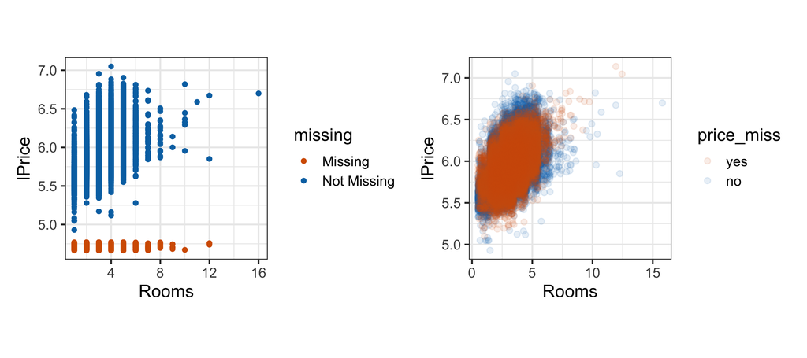

```r
mp1 <- ggplot(df2, aes(x=Rooms, y=lPrice)) +
  geom_miss_point()

mp2 <- ggplot(df2_nomiss, aes(x=Rooms,
                               y=lPrice,
                               colour=price_miss)) +
  geom_jitter(width=0.5, alpha=0.1)

mp3 <- df2_nomiss |>
  ggplot() +
  geom_histogram(aes(x=Price / 1e6,
                     y=after_stat(density)),
                 color = "white") +
  facet_wrap(~price_miss, ncol=2,
              scales="free_y") +
  labs(
    x = "Price (mil)",
    y = "Count"
  ) +
  scale_x_log10()
mp1 + mp2 + plot_layout(ncol=2)
```

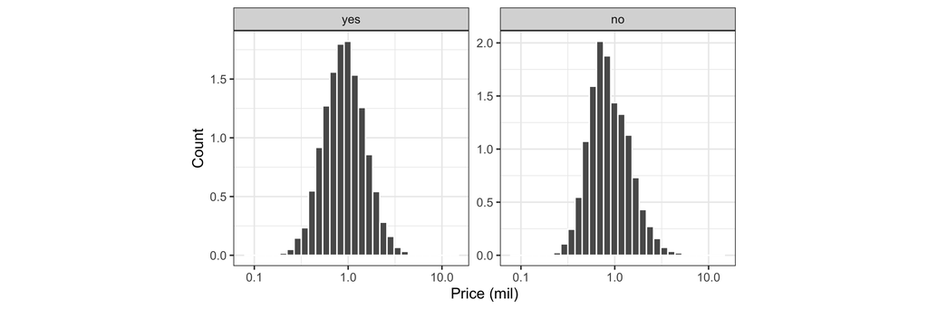

```r
mp3
```

Categorical variable: Simulate from multinomial.

```r
tb_oz_age <- tb |>
  filter(iso3 == "AUS", year == 2012) |>
  select(contains("new_sp_f")) |>
  select(-new_sp_f04, -new_sp_f514, -new_sp_f014) |>
  pivot_longer(new_sp_f1524:new_sp_fu,
    names_to="age",
    values_to="count") |>
  mutate(age = str_remove(age, "new_sp_f"))
# Add some missing count
tb_oz_age$count[7] <- 12
tb_oz_age
```

```
# A tibble: 7 × 2
  age   count
  <chr> <dbl>
1 1524     27
2 2534     48
3 3544     15
4 4554     11
5 5564      9
6 65       15
7 u        12
```

```r
tb_oz_age_long <- tb_oz_age |>
  uncount(count) |>
  mutate(age = ifelse(age == "u", NA, age))
set.seed(153)
fill_miss <- rbinom(tb_oz_age$count[7], size=5,
  prob=tb_oz_age$count[1:6]/sum(tb_oz_age$count[1:6]))+1
tb_oz_age_impute <- tb_oz_age
for (i in 1:length(fill_miss))
  tb_oz_age_impute$count[fill_miss[i]] <-
    tb_oz_age_impute$count[fill_miss[i]] + 1
fill_miss
```

```
 [1] 5 3 1 1 2 1 1 2 1 1 1 1
```

```r
tb_oz_age_impute
```

```
# A tibble: 7 × 2
  age   count
  <chr> <dbl>
1 1524     35
2 2534     50
3 3544     16
4 4554     11
5 5564     10
6 65       15
7 u        12
```

`imputeMulti` library can automate for multiple variables.

## Key points

- Make many plots of a single variable (histogram, density, boxplot, quasirandom) – the type of plot, and choices like bin width or bandwidth, change what patterns are visible
- Use simulation and permutation to generate null samples and lineups, to judge whether a striking feature (outlier, cluster, shape) is more than what’s expected by chance
- Compute both non-robust (mean, SD) and robust (median, MAD, IQR, trimmed/winsorised mean) statistics – skew and outliers can pull the non-robust ones a long way from the bulk of the data
- Boxplots are a compact robust summary, but can hide multimodality – check against the raw data
- Transformations (e.g. Box-Cox, the ladder of power transformations) can re-focus attention and symmetrise skewed data, but round the “optimal” $\lambda$ with care, especially when extreme outliers are present
- Check for missing values early: visualise the pattern of missingness (e.g. `vis_miss()`, a lineup) before deciding how, or whether, to impute – and script decisions so they can be reversed
- For a categorical variable, compute counts, proportions/percentages and odds, and order categories meaningfully rather than relying on the default ordering

## Resources

- Unwin (2015) Graphical Data Analysis with R
- Venables, W. N. & Ripley, B. D. (2002) Modern Applied Statistics with S. Fourth Edition. Springer, New York. ISBN 0-387-95457-0
- Josse et al (2022) [R-miss-tastic](https://rmisstastic.netlify.app)
- Wilke [Fundamentals of Data Visualization](https://clauswilke.com/dataviz/), chapters 6-11.